# IODS course project

## Analysis

### Standardizing the data

```r
# 4.
# standardizing the dataset
boston_scaled <- scale(Boston)
boston_scaled <- as.data.frame(boston_scaled)

# categorizing the crime rate
bins <- quantile(boston_scaled$crim)
crime <- cut(boston_scaled$crim, breaks = bins, include.lowest = TRUE, labels=c("low", "med_low", "med_high", "high"))

#replacing the old crime rate with the categorized variable
boston_scaled <- dplyr::select(boston_scaled, -crim)
boston_scaled <- data.frame(boston_scaled, crime)
summary(boston_scaled)
```

```
##        zn               indus              chas              nox
##  Min.   :-0.48724   Min.   :-1.5563   Min.   :-0.2723   Min.   :-1.4644
##  1st Qu.:-0.48724   1st Qu.:-0.8668   1st Qu.:-0.2723   1st Qu.:-0.9121
##  Median :-0.48724   Median :-0.2109   Median :-0.2723   Median :-0.1441
##  Mean   : 0.00000   Mean   : 0.0000   Mean   : 0.0000   Mean   : 0.0000
##  3rd Qu.: 0.04872   3rd Qu.: 1.0150   3rd Qu.:-0.2723   3rd Qu.: 0.5981
##  Max.   : 3.80047   Max.   : 2.4202   Max.   : 3.6648   Max.   : 2.7296
##        rm               age               dis               rad
##  Min.   :-3.8764   Min.   :-2.3331   Min.   :-1.2658   Min.   :-0.9819
##  1st Qu.:-0.5681   1st Qu.:-0.8366   1st Qu.:-0.8049   1st Qu.:-0.6373
##  Median :-0.1084   Median : 0.3171   Median :-0.2790   Median :-0.5225
##  Mean   : 0.0000   Mean   : 0.0000   Mean   : 0.0000   Mean   : 0.0000
##  3rd Qu.: 0.4823   3rd Qu.: 0.9059   3rd Qu.: 0.6617   3rd Qu.: 1.6596
##  Max.   : 3.5515   Max.   : 1.1164   Max.   : 3.9566   Max.   : 1.6596
##       tax             ptratio            black             lstat
##  Min.   :-1.3127   Min.   :-2.7047   Min.   :-3.9033   Min.   :-1.5296
##  1st Qu.:-0.7668   1st Qu.:-0.4876   1st Qu.: 0.2049   1st Qu.:-0.7986
##  Median :-0.4642   Median : 0.2746   Median : 0.3808   Median :-0.1811
##  Mean   : 0.0000   Mean   : 0.0000   Mean   : 0.0000   Mean   : 0.0000
##  3rd Qu.: 1.5294   3rd Qu.: 0.8058   3rd Qu.: 0.4332   3rd Qu.: 0.6024
##  Max.   : 1.7964   Max.   : 1.6372   Max.   : 0.4406   Max.   : 3.5453
##       medv              crime
##  Min.   :-1.9063   low     :127
##  1st Qu.:-0.5989   med_low :126
##  Median :-0.1449   med_high:126
##  Mean   : 0.0000   high    :127
##  3rd Qu.: 0.2683
##  Max.   : 2.9865
```

Above you can find a summary of the scaled dataset and categorized crime rate. After the scaling of the dataset and categorization of the crime rate variable, we will divide the data set into train (80 %) and test (20 %) sets.

```r
# dividing the train and test sets
n <- nrow(boston_scaled)
ind <- sample(n,  size = n * 0.8)
train <- boston_scaled[ind,]
test <- boston_scaled[-ind,]
```

### Classification

```r
# 5. fitting an LDA on the train set
lda.fit <- lda(train$crime ~ ., data = train)
lda.fit
```

```
## Call:
## lda(train$crime ~ ., data = train)
##
## Prior probabilities of groups:
##       low   med_low  med_high      high
## 0.2450495 0.2524752 0.2301980 0.2722772
##
## Group means:
##                  zn      indus         chas        nox         rm
## low       1.0478912 -0.8890656 -0.113254311 -0.8781300  0.4182084
## med_low  -0.1206827 -0.2584207 -0.002135914 -0.5185401 -0.1695022
## med_high -0.3848883  0.1292444  0.193349455  0.3654539  0.1375044
## high     -0.4872402  1.0169558 -0.057578146  1.0262031 -0.3652161
##                 age        dis        rad        tax    ptratio      black
## low      -0.8924470  0.8786286 -0.6883741 -0.7336140 -0.4558298  0.3754757
## med_low  -0.3273005  0.2842749 -0.5506331 -0.4800356 -0.0745589  0.3566851
## med_high  0.4064544 -0.3656492 -0.3989933 -0.3308710 -0.3425283  0.1067797
## high      0.8085458 -0.8495001  1.6397657  1.5152267  0.7826832 -0.7505195
##                 lstat         medv
## low      -0.765615260  0.498567315
## med_low  -0.136771080 -0.004739605
## med_high  0.001061736  0.239263032
## high      0.876789743 -0.662371239
##
## Coefficients of linear discriminants:
##                  LD1         LD2          LD3
## zn       0.113556465  0.97748188 -0.840390923
## indus    0.044002387 -0.15511190  0.239072046
## chas    -0.002942476 -0.05442851  0.052708110
## nox      0.465960301 -0.51640663 -1.347830866
## rm       0.033340939 -0.06951904 -0.250671506
## age      0.197985840 -0.30656904 -0.324768989
## dis     -0.071761482 -0.34237371  0.003878054
## rad      3.363773929  0.86199386 -0.041602017
## tax      0.011750201 -0.13174195  0.570430075
## ptratio  0.145232065  0.15389288 -0.222670672
## black   -0.128577554  0.01521454  0.167026568
## lstat    0.201308321 -0.35610036  0.321280697
## medv     0.095020083 -0.47867129 -0.228974818
##
## Proportion of trace:
##    LD1    LD2    LD3
## 0.9553 0.0336 0.0110
```

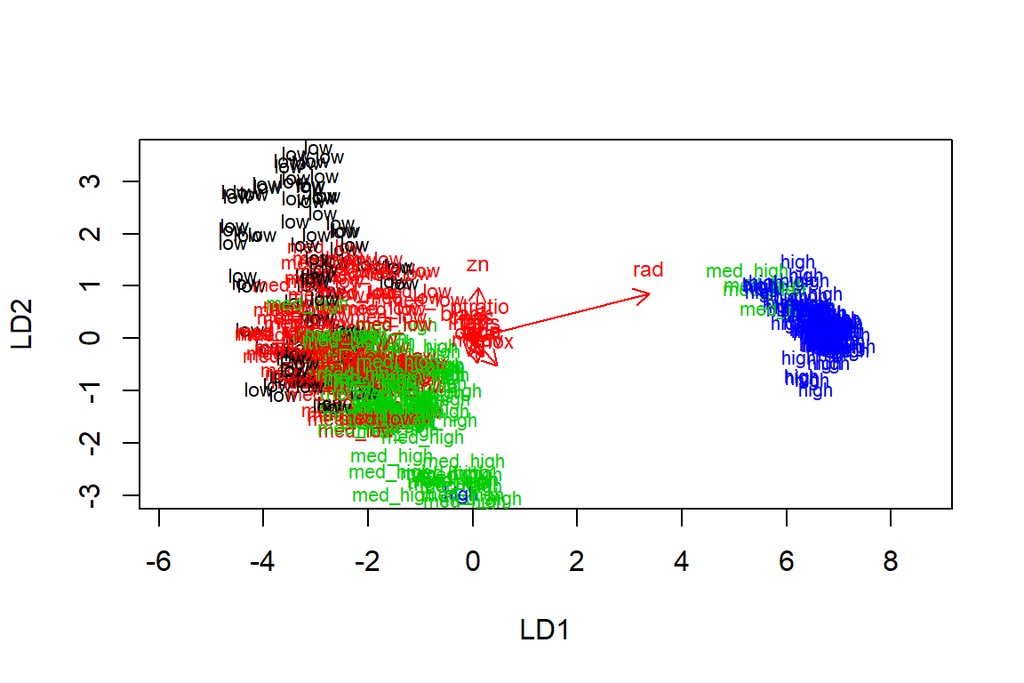

```r
# defining the arrow function
lda.arrows <- function(x, myscale = 1, arrow_heads = 0.1, color = "red", tex = 0.75, choices = c(1,2)){
  heads <- coef(x)
  arrows(x0 = 0, y0 = 0,
         x1 = myscale * heads[,choices[1]],
         y1 = myscale * heads[,choices[2]], col=color, length = arrow_heads)
  text(myscale * heads[,choices], labels = row.names(heads),
       cex = tex, col=color, pos=3)
}

# target classes as numeric (for plotting purposes)
classes <- as.numeric(train$crime)

# plotting the results (paint both lines to execute)
plot(lda.fit, dimen = 2, col=classes, pch=classes)
lda.arrows(lda.fit, myscale = 1)
```

**Figure 2.** The scatter plot of the linear discriminant analysis on crime rate.

Based on our linear discriminant analysis it would seem our crime rate variable is indeed best predicted by index of accessibility to radial highways, a connection we already saw in the correlations.

### Prediction

Next we will attempt to predict the classes of the test data based on our model created above.

```r
# 6.
# saving the crime categories from the test set and then removing the categorical crime variable from the test dataset
correct_classes <- test$crime
test <- dplyr::select(test, -crime)

# predicting the classes with the LDA model on the test data
lda.pred <- predict(lda.fit, newdata = test)

# cross tabulating the results
table(correct = correct_classes, predicted = lda.pred$class)
```

```
##           predicted
## correct    low med_low med_high high
##   low       12      13        3    0
##   med_low    4      19        1    0
##   med_high   0      12       19    2
##   high       0       0        0   17
```

It would seem most of our actual test observations match the model predictions, which validates the model.

### K-means clustering

Next we will reload and scale the Boston data set and use an unsupervised clustering method to assign observations to clusters based on similarity.

```r
# Euclidean distances
dist_eu <- dist(Boston)
summary(dist_eu)
```

```
##    Min. 1st Qu.  Median    Mean 3rd Qu.    Max.
##  0.1343  3.4625  4.8241  4.9111  6.1863 14.3970
```

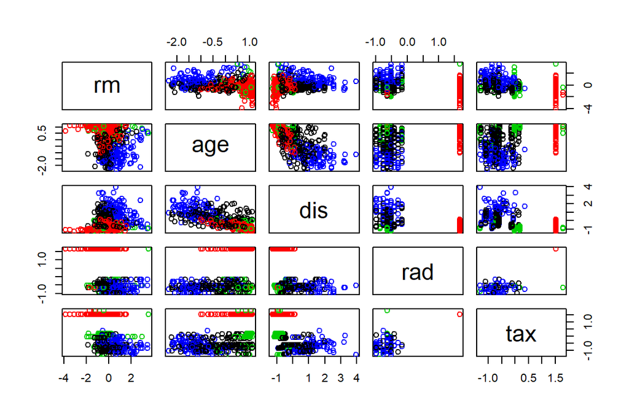

```r
# k-means clustering and plotting
km <-kmeans(Boston, centers = 4)
pairs(Boston[6:10], col = km$cluster)
```

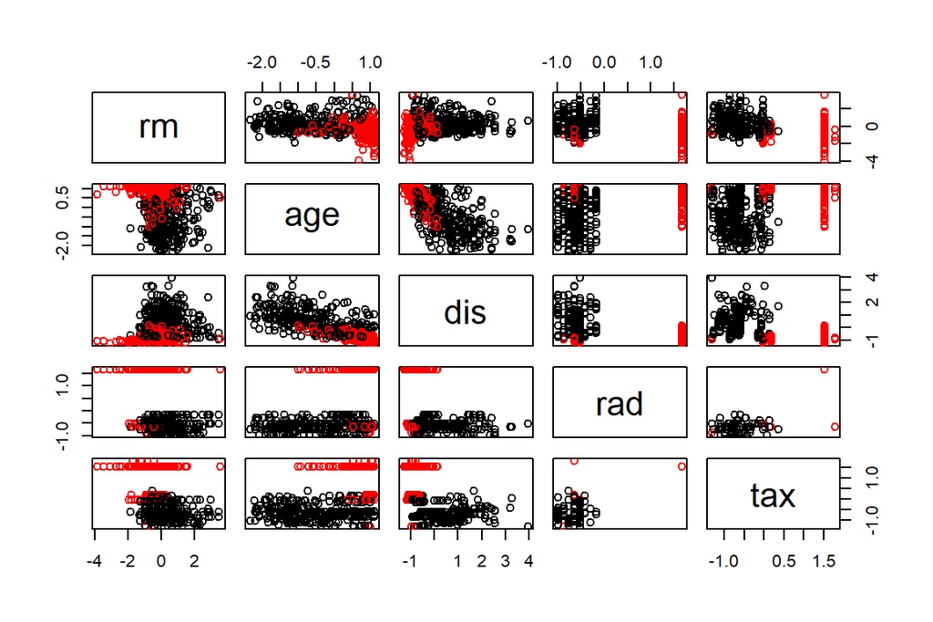

```r
km <-kmeans(Boston, centers = 2)
pairs(Boston[6:10], col = km$cluster)
```

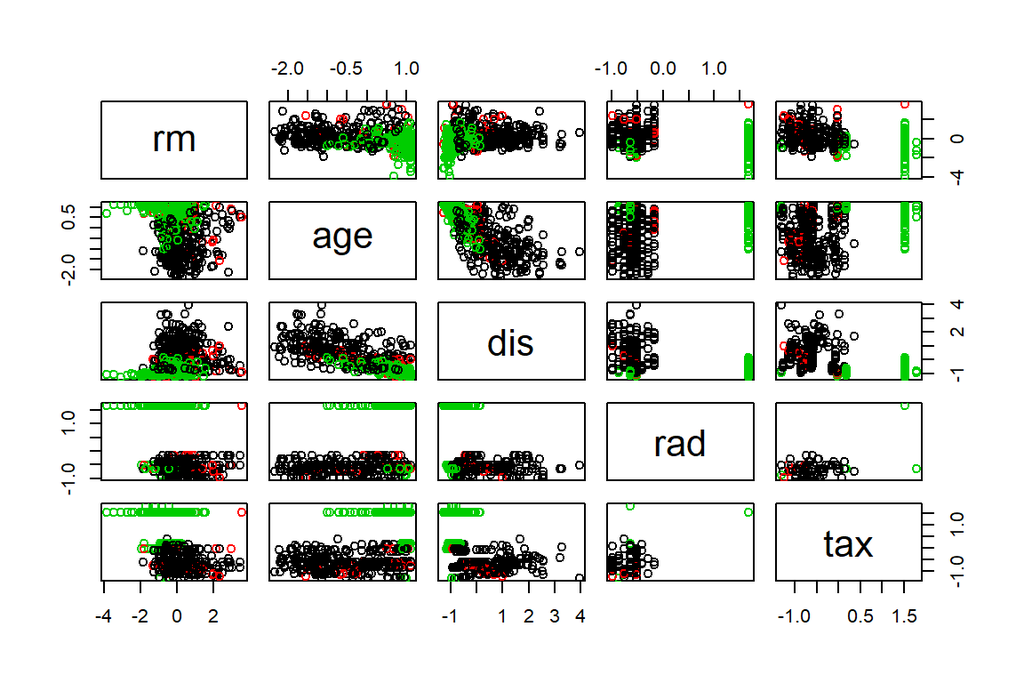

```r
km <-kmeans(Boston, centers = 3)
pairs(Boston[6:10], col = km$cluster)
```

# Exercise 5: Dimensionality reduction techniques

## Principal Component Analysis

### Data

Our dataset “human” contains 155 observations of 8 variables. The dataset combines elements from the measures “Human Development Index” and “Gender Inequality Index” from the Human Development Report 2015. A summary of the data can be seen below.

```r
# Step 1. graphical overview of the data
human <- read.table("http://s3.amazonaws.com/assets.datacamp.com/production/course_2218/datasets/human2.txt", sep=",", header=TRUE)

str(human)
```

```
## 'data.frame':    155 obs. of  8 variables:
##  $ Edu2.FM  : num  1.007 0.997 0.983 0.989 0.969 ...
##  $ Labo.FM  : num  0.891 0.819 0.825 0.884 0.829 ...
##  $ Edu.Exp  : num  17.5 20.2 15.8 18.7 17.9 16.5 18.6 16.5 15.9 19.2 ...
##  $ Life.Exp : num  81.6 82.4 83 80.2 81.6 80.9 80.9 79.1 82 81.8 ...
##  $ GNI      : int  64992 42261 56431 44025 45435 43919 39568 52947 42155 32689 ...
##  $ Mat.Mor  : int  4 6 6 5 6 7 9 28 11 8 ...
##  $ Ado.Birth: num  7.8 12.1 1.9 5.1 6.2 3.8 8.2 31 14.5 25.3 ...
##  $ Parli.F  : num  39.6 30.5 28.5 38 36.9 36.9 19.9 19.4 28.2 31.4 ...
```

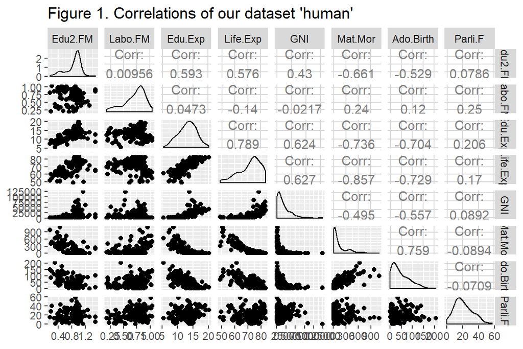

```r
ggpairs(human, title = "Figure 1. Correlations of our dataset 'human'")
```

```r
summary(human)
```

```
##     Edu2.FM          Labo.FM          Edu.Exp         Life.Exp
##  Min.   :0.1717   Min.   :0.1857   Min.   : 5.40   Min.   :49.00
##  1st Qu.:0.7264   1st Qu.:0.5984   1st Qu.:11.25   1st Qu.:66.30
##  Median :0.9375   Median :0.7535   Median :13.50   Median :74.20
##  Mean   :0.8529   Mean   :0.7074   Mean   :13.18   Mean   :71.65
##  3rd Qu.:0.9968   3rd Qu.:0.8535   3rd Qu.:15.20   3rd Qu.:77.25
##  Max.   :1.4967   Max.   :1.0380   Max.   :20.20   Max.   :83.50
##       GNI            Mat.Mor         Ado.Birth         Parli.F
##  Min.   :   581   Min.   :   1.0   Min.   :  0.60   Min.   : 0.00
##  1st Qu.:  4198   1st Qu.:  11.5   1st Qu.: 12.65   1st Qu.:12.40
##  Median : 12040   Median :  49.0   Median : 33.60   Median :19.30
##  Mean   : 17628   Mean   : 149.1   Mean   : 47.16   Mean   :20.91
##  3rd Qu.: 24512   3rd Qu.: 190.0   3rd Qu.: 71.95   3rd Qu.:27.95
##  Max.   :123124   Max.   :1100.0   Max.   :204.80   Max.   :57.50
```

As the Figure 1 above displays, the variables portraying female-male -ratio of labour participation and expected years of education are quite normally distributed. The other variables are skew towards the right, apart from the female-male -ratio of secondary education acquisition, which contains two peaks. The correlations seem to be significantly positive between life expectancy and expected years of education, GNI per capita and life expectancy, as well as maternal mortality at birth and adolescent birth rate. Significantly negative correlations can be observed between maternal mortality at birth and female-male ratio in secondary education acquisition, maternal mortality at birth and expected years of education, expected years of education and adolescent birth rate, maternal mortality at birth and life expectancy, as well as adolescent birth rate and life expectancy.

### Analysis

```r
# Step 2. perform principal component analysis on the original data

pca_human <- prcomp(human)

# create a summary of pca_human
s <- summary(pca_human)

# rounded percetanges of variance captured by each PC
pca_pr <- round(100*s$importance[2, ], digits = 1)

# print out the percentages of variance
pca_pr
```

```
## PC1 PC2 PC3 PC4 PC5 PC6 PC7 PC8
## 100   0   0   0   0   0   0   0
```

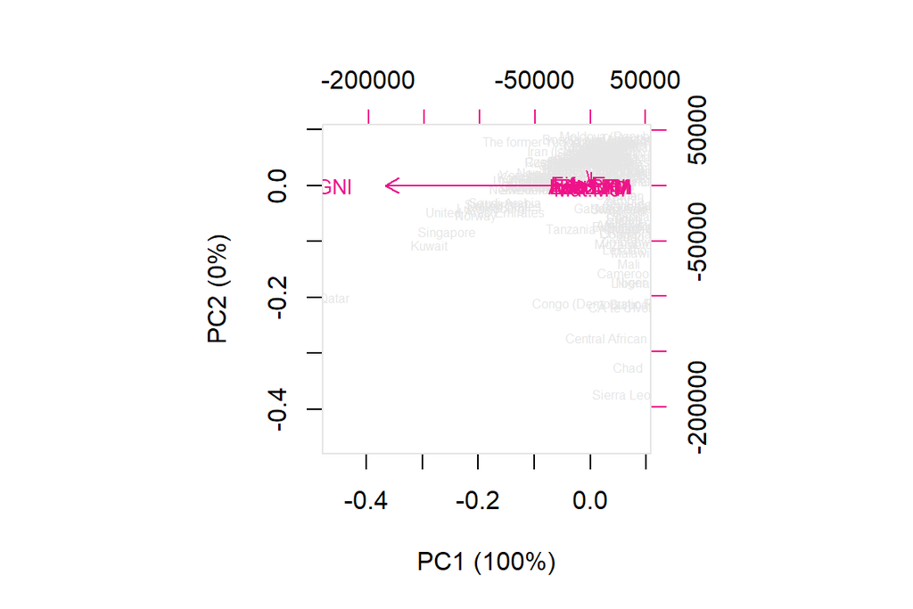

```r
# create object pc_lab to be used as axis labels
pc_lab <- paste0(names(pca_pr), " (", pca_pr, "%)")

# draw a biplot
biplot(pca_human, cex = c(0.5, 0.8), col = c("grey90", "deeppink2"), xlab = pc_lab[1], ylab = pc_lab[2])
```

```r
# Step 2. perform principal component analysis on the standardized data

# standardizing the variable
human_std <- scale(human)

# perform principal component analysis (with the SVD method)
pca_human <- prcomp(human_std)

# create a summary of pca_human
s <- summary(pca_human)

# rounded percetanges of variance captured by each PC
pca_pr <- round(100*s$importance[2, ], digits = 1)

# print out the percentages of variance
pca_pr
```

```
##  PC1  PC2  PC3  PC4  PC5  PC6  PC7  PC8
## 53.6 16.2  9.6  7.6  5.5  3.6  2.6  1.3
```

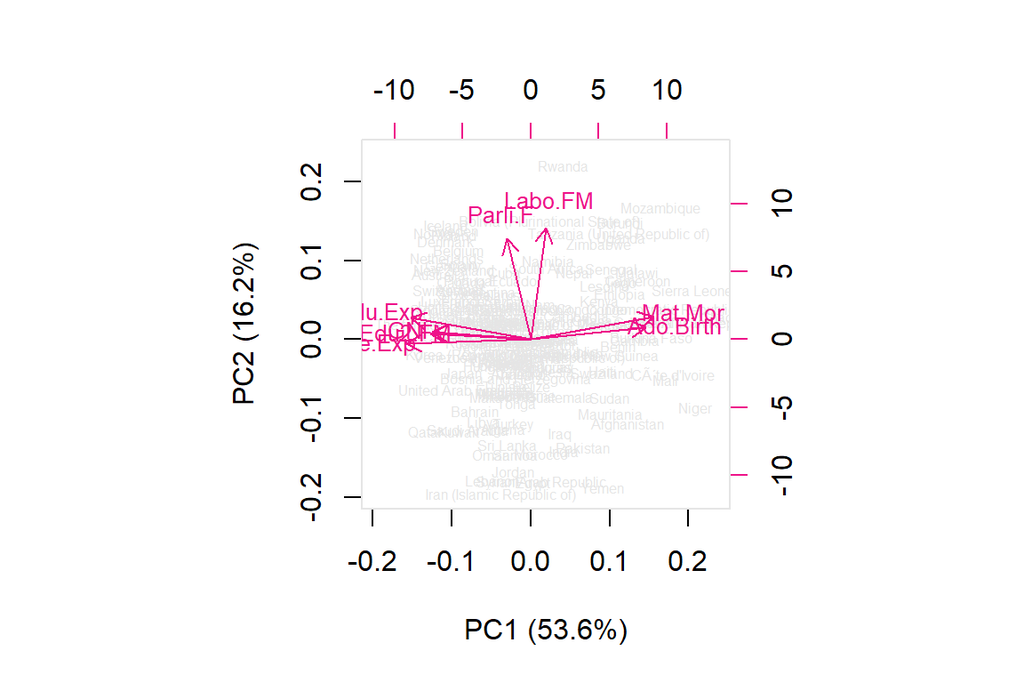

```r
# create object pc_lab to be used as axis labels
pc_lab <- paste0(names(pca_pr), " (", pca_pr, "%)")

# draw a biplot
biplot(pca_human, cex = c(0.5, 0.8), col = c("grey90", "deeppink2"), xlab = pc_lab[1], ylab = pc_lab[2])
```

**Figure 3.** PCA on the standardized data.

The above firgure 3. displays the following loading of variables on the first principal component: maternal mortality ratio, adolescent birth ratio and the reversed versions of expected years of education, secondary education ratio (of female-male), GNI per capita and life expectancy. The second principal component would then consist of labour participation rate and percentage of female representation in parliament. Thus, the first principal component contains variables especially related to the “life in years”, so-called, of a country’s population, with factors such as education and birth control having positive correlations with life expectancy and maternal conditions. The second principal component portrays factors related to societal and working life development.

## Multiple Correspondence Analysis

Next we will conduct a multiple correspondence analysis on a a subset of categories from the dataset “tea” called “tea-time”.

```r
# Step 5. MCA on tea_time
# For some currentlty unexplicable reason I am unable to knit this with the index file, so I will display as comment here what I have done, and attatch the MCA plot png along with the interpretation.
library(FactoMineR);library(ggplot2);library(dplyr);library(tidyr)

data(tea)
str(tea)
```

```
## 'data.frame':    300 obs. of  36 variables:
##  $ breakfast       : Factor w/ 2 levels "breakfast","Not.breakfast": 1 1 2 2 1 2 1 2 1 1 ...
##  $ tea.time        : Factor w/ 2 levels "Not.tea time",..: 1 1 2 1 1 1 2 2 2 1 ...
##  $ evening         : Factor w/ 2 levels "evening","Not.evening": 2 2 1 2 1 2 2 1 2 1 ...
##  $ lunch           : Factor w/ 2 levels "lunch","Not.lunch": 2 2 2 2 2 2 2 2 2 2 ...
##  $ dinner          : Factor w/ 2 levels "dinner","Not.dinner": 2 2 1 1 2 1 2 2 2 2 ...
##  $ always          : Factor w/ 2 levels "always","Not.always": 2 2 2 2 1 2 2 2 2 2 ...
##  $ home            : Factor w/ 2 levels "home","Not.home": 1 1 1 1 1 1 1 1 1 1 ...
##  $ work            : Factor w/ 2 levels "Not.work","work": 1 1 2 1 1 1 1 1 1 1 ...
##  $ tearoom         : Factor w/ 2 levels "Not.tearoom",..: 1 1 1 1 1 1 1 1 1 2 ...
##  $ friends         : Factor w/ 2 levels "friends","Not.friends": 2 2 1 2 2 2 1 2 2 2 ...
##  $ resto           : Factor w/ 2 levels "Not.resto","resto": 1 1 2 1 1 1 1 1 1 1 ...
##  $ pub             : Factor w/ 2 levels "Not.pub","pub": 1 1 1 1 1 1 1 1 1 1 ...
##  $ Tea             : Factor w/ 3 levels "black","Earl Grey",..: 1 1 2 2 2 2 2 1 2 1 ...
##  $ How             : Factor w/ 4 levels "alone","lemon",..: 1 3 1 1 1 1 1 3 3 1 ...
```

[output cut: 22 more lines]

```r
# column names to keep in the dataset
keep_columns <- c("Tea", "How", "how", "sugar", "where", "lunch")
tea_time <- subset(tea, select=c("Tea", "How", "how", "sugar", "where", "lunch"))

summary(tea_time)
```

```
##         Tea         How                      how           sugar
##  black    : 74   alone:195   tea bag           :170   No.sugar:155
##  Earl Grey:193   lemon: 33   tea bag+unpackaged: 94   sugar   :145
##  green    : 33   milk : 63   unpackaged        : 36
##                  other:  9
##                   where           lunch
##  chain store         :192   lunch    : 44
##  chain store+tea shop: 78   Not.lunch:256
##  tea shop            : 30
##
```

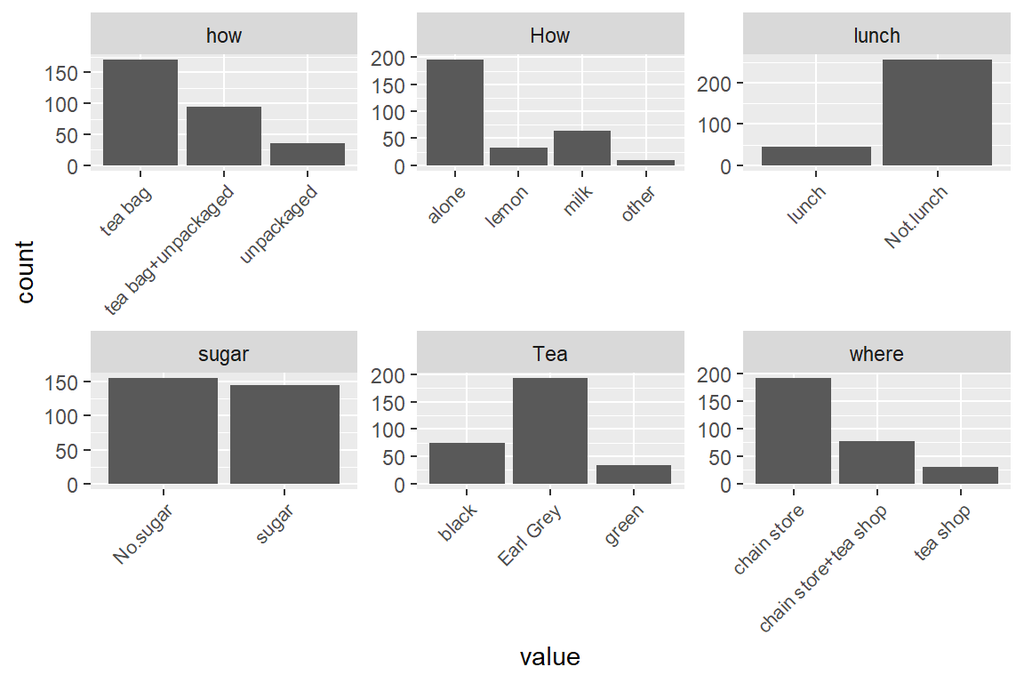

```r
gather(tea_time) %>% ggplot(aes(value)) + facet_wrap("key", scales = "free") + geom_bar() + theme(axis.text.x = element_text(angle = 45, hjust = 1, size = 8))
```

```r
# multiple correspondence analysis
mca <- MCA(tea_time, graph = FALSE)

# summary of the mode
summary(mca)
```

```
##
## Call:
## MCA(X = tea_time, graph = FALSE)
##
##
## Eigenvalues
##                        Dim.1   Dim.2   Dim.3   Dim.4   Dim.5   Dim.6
## Variance               0.279   0.261   0.219   0.189   0.177   0.156
## % of var.             15.238  14.232  11.964  10.333   9.667   8.519
## Cumulative % of var.  15.238  29.471  41.435  51.768  61.434  69.953
##                        Dim.7   Dim.8   Dim.9  Dim.10  Dim.11
## Variance               0.144   0.141   0.117   0.087   0.062
## % of var.              7.841   7.705   6.392   4.724   3.385
## Cumulative % of var.  77.794  85.500  91.891  96.615 100.000
##
## Individuals (the 10 first)
##                       Dim.1    ctr   cos2    Dim.2    ctr   cos2    Dim.3
## 1                  | -0.298  0.106  0.086 | -0.328  0.137  0.105 | -0.327
## 2                  | -0.237  0.067  0.036 | -0.136  0.024  0.012 | -0.695
## 3                  | -0.369  0.162  0.231 | -0.300  0.115  0.153 | -0.202
## 4                  | -0.530  0.335  0.460 | -0.318  0.129  0.166 |  0.211
## 5                  | -0.369  0.162  0.231 | -0.300  0.115  0.153 | -0.202
## 6                  | -0.369  0.162  0.231 | -0.300  0.115  0.153 | -0.202
## 7                  | -0.369  0.162  0.231 | -0.300  0.115  0.153 | -0.202
## 8                  | -0.237  0.067  0.036 | -0.136  0.024  0.012 | -0.695
## 9                  |  0.143  0.024  0.012 |  0.871  0.969  0.435 | -0.067
## 10                 |  0.476  0.271  0.140 |  0.687  0.604  0.291 | -0.650
##                       ctr   cos2
## 1                   0.163  0.104 |
## 2                   0.735  0.314 |
## 3                   0.062  0.069 |
## 4                   0.068  0.073 |
## 5                   0.062  0.069 |
## 6                   0.062  0.069 |
## 7                   0.062  0.069 |
## 8                   0.735  0.314 |
## 9                   0.007  0.003 |
## 10                  0.643  0.261 |
##
## Categories (the 10 first)
```

[output cut: 16 more lines]

```
## lemon                0.035   3.226 |   1.329  14.771   0.218   8.081 |
## milk                 0.020   2.422 |   0.013   0.003   0.000   0.116 |
## other                0.102   5.534 |  -2.524  14.526   0.197  -7.676 |
## tea bag              0.161  -6.941 |  -0.065   0.183   0.006  -1.287 |
## tea bag+unpackaged   0.478  11.956 |   0.019   0.009   0.000   0.226 |
## unpackaged           0.141  -6.482 |   0.257   0.602   0.009   1.640 |
##
## Categorical variables (eta2)
##                      Dim.1 Dim.2 Dim.3
## Tea                | 0.126 0.108 0.410 |
## How                | 0.076 0.190 0.394 |
## how                | 0.708 0.522 0.010 |
## sugar              | 0.065 0.001 0.336 |
## where              | 0.702 0.681 0.055 |
## lunch              | 0.000 0.064 0.111 |
```

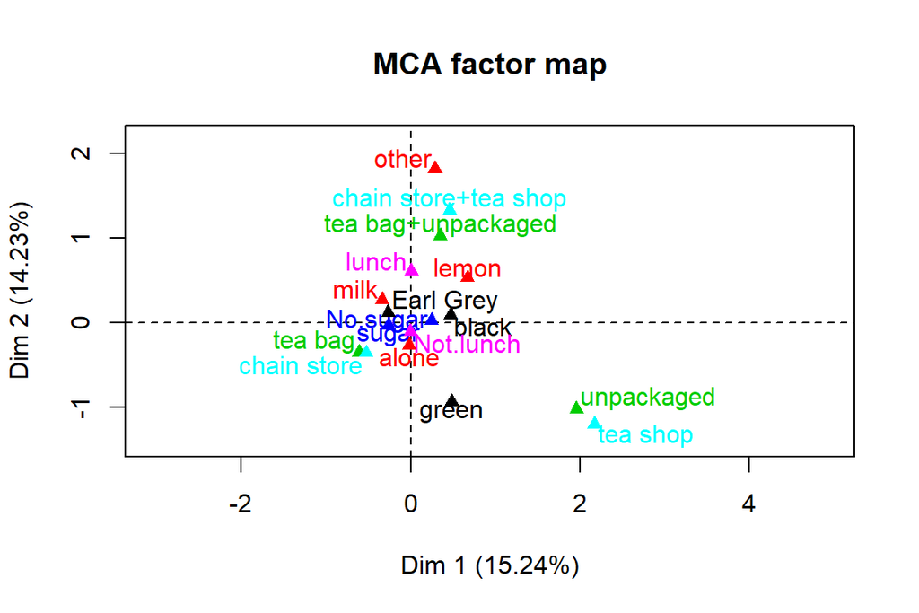

```r
# visualize MCA
plot(mca, invisible=c("ind"), habillage = "quali")
```

**Figure 1.** The multiple correspondence analysis on categories from “tea-time”.

The MCA output in Figure 1 shows us that unpackaged tea bags occur often together with chain stores and tea shops. Lunch and lemon are moderately co-occuring with these, as well as with milk, Earl Grey and black tea without sugar. Chain stores and tea bags often occur together with alone time which is not lunch, and with sugar. Unpackaged tea often co-occurs with tea shops and green tea. This is a fairly confusing explanation, and could have been explained more explicitly, but by writing this I see where this is going and it seems really handy and interesting way of analyzing qualitative data!

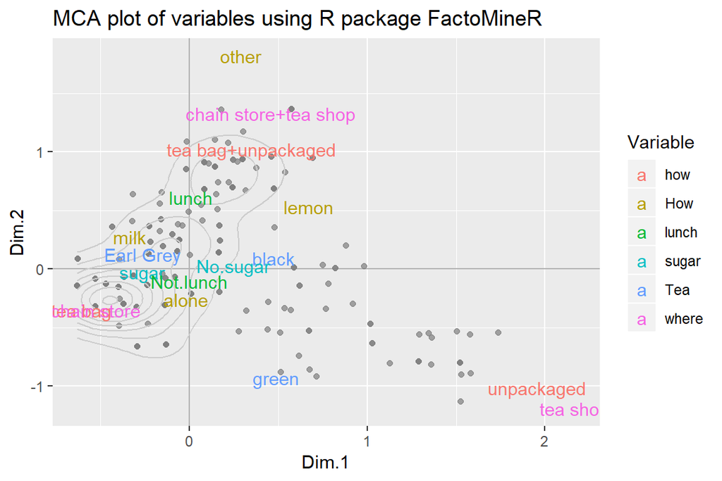

```r
cats <- apply(tea_time, 2, function(x) nlevels(as.factor(x)))

# data frame with variable coordinates
mca1_vars_df = data.frame(mca$var$coord, Variable = rep(names(cats), cats))

# data frame with observation coordinates
mca1_obs_df = data.frame(mca$ind$coord)

# plot of variable categories
ggplot(data = mca1_obs_df, aes(x = Dim.1, y = Dim.2)) +
  geom_hline(yintercept = 0, colour = "gray70") +
  geom_vline(xintercept = 0, colour = "gray70") +
  geom_point(colour = "gray50", alpha = 0.7) +
  geom_density2d(colour = "gray80") +
  geom_text(data = mca1_vars_df,
            aes(x = Dim.1, y = Dim.2,
                label = rownames(mca1_vars_df), colour = Variable)) +
  ggtitle("MCA plot of variables using R package FactoMineR") +
  scale_colour_discrete(name = "Variable")
```